# 17b - Mock Analysis: Dimension Reduction and Clustering

Biostatistics 735/794 — Machine Learning in Public Health

Author

Alexander McLain

Published

October 19, 2026

These are the worked analyses for the three in-class mock-analysis handouts (`Mock-Analysis-Handouts-DR-Clustering.docx`). In each scenario we go step by step:

1. **Look at the data** before running anything.
2. **Try the “obvious” analysis** and see what goes wrong.
3. **Fix the problem** and redo the analysis.
4. **Check the answer**: is the structure real, and can we use it?

The big lesson across all three: dimension reduction and clustering methods will *always* give you an answer. They never warn you that you put the wrong variables in. Most of the work is deciding what goes in.

| Group | Data | Main issue | Method we end up with |
| --- | --- | --- | --- |
| 1 | NHANES adults | What goes into the distance; are there clusters at all? | PAM on the numeric measures (and a new idea: Gower distance) |
| 2 | `bfi` personality survey | Finding a few underlying traits and scoring new people the same way | Factor analysis |
| 3 | Communities and Crime | ~100 overlapping variables, size variables, the outcome in the data, and new communities | PCA, then K-means on the PC scores |

```r
set.seed(735794)
library(tidyverse)
library(janitor)
library(kableExtra)
library(NHANES)
library(psych)
library(GPArotation)  # needed for the oblimin rotation in fa()
library(cluster)      # daisy(), pam(), silhouette(), clusGap()
library(factoextra)
library(mclust)       # Mclust(), adjustedRandIndex()
library(uwot)

select <- dplyr::select
count  <- dplyr::count
kbl2 <- function(x, ...) kable(x, ...) |> kable_styling(full_width = FALSE)
```

# 1 Scenario 1: Cardiometabolic Phenotypes in NHANES

**Goal:** Find subgroups (“phenotypes”) of U.S. adults with similar cardiometabolic profiles, and report how diabetes prevalence differs across them.

## 1.1 Step 1: Look at the Data

```r
adults <- NHANES |>
  clean_names() |>
  filter(age >= 20)

# Rows vs. people
c(rows = nrow(adults), people = n_distinct(adults$id))
```

```
  rows people
  7235   4654
```

There are about 2,600 more rows than people. The `NHANES` package was made by *resampling* the real survey, so many people appear two or more times. If we keep the copies, every copied person has a “twin” at distance 0, and those twins make tight little groups that aren’t real. **Keep one row per person.**

```r
adults |>
  select(age, gender, bmi, weight, height, bp_sys_ave, bp_dia_ave, pulse,
         tot_chol, direct_chol, smoke100, phys_active, diabetes) |>
  glimpse()
```

```
Rows: 7,235
Columns: 13
$ age         <int> 34, 34, 34, 49, 45, 45, 45, 66, 58, 54, 58, 50, 33, 60, 56…
$ gender      <fct> male, male, male, female, female, female, female, male, ma…
$ bmi         <dbl> 32.22, 32.22, 32.22, 30.57, 27.24, 27.24, 27.24, 23.67, 23…
$ weight      <dbl> 87.4, 87.4, 87.4, 86.7, 75.7, 75.7, 75.7, 68.0, 78.4, 74.7…
$ height      <dbl> 164.7, 164.7, 164.7, 168.4, 166.7, 166.7, 166.7, 169.5, 18…
$ bp_sys_ave  <int> 113, 113, 113, 112, 118, 118, 118, 111, 104, 134, 127, 142…
$ bp_dia_ave  <int> 85, 85, 85, 75, 64, 64, 64, 63, 74, 85, 83, 68, 74, 100, 6…
$ pulse       <int> 70, 70, 70, 86, 62, 62, 62, 60, 62, 76, 94, 74, 96, 84, 64…
$ tot_chol    <dbl> 3.49, 3.49, 3.49, 6.70, 5.82, 5.82, 5.82, 4.99, 4.24, 6.41…
$ direct_chol <dbl> 1.29, 1.29, 1.29, 1.16, 2.12, 2.12, 2.12, 0.67, 0.96, 1.16…
$ smoke100    <fct> Yes, Yes, Yes, Yes, No, No, No, Yes, No, No, Yes, No, Yes,…
$ phys_active <fct> No, No, No, No, Yes, Yes, Yes, Yes, Yes, Yes, Yes, Yes, No…
$ diabetes    <fct> No, No, No, No, No, No, No, No, No, No, No, No, No, No, No…
```

Some variables are numbers (`<dbl>`, `<int>`) and some are categories (`<fct>`): gender, smoking (`smoke100` = smoked at least 100 cigarettes), physical activity, and diabetes.

```r
adults |>
  select(bmi, weight, height, bp_sys_ave, bp_sys1, bp_sys2, bp_sys3) |>
  cor(use = "complete.obs") |>
  round(2)
```

```
             bmi weight height bp_sys_ave bp_sys1 bp_sys2 bp_sys3
bmi         1.00   0.88  -0.01       0.12    0.12    0.12    0.13
weight      0.88   1.00   0.46       0.11    0.10    0.11    0.12
height     -0.01   0.46   1.00       0.00   -0.01   -0.01    0.01
bp_sys_ave  0.12   0.11   0.00       1.00    0.95    0.99    0.99
bp_sys1     0.12   0.10  -0.01       0.95    1.00    0.94    0.93
bp_sys2     0.12   0.11  -0.01       0.99    0.94    1.00    0.95
bp_sys3     0.13   0.12   0.01       0.99    0.93    0.95    1.00
```

BMI and weight are correlated about 0.9, and the individual BP readings are correlated about 0.95 with their average. They measure nearly the same thing.

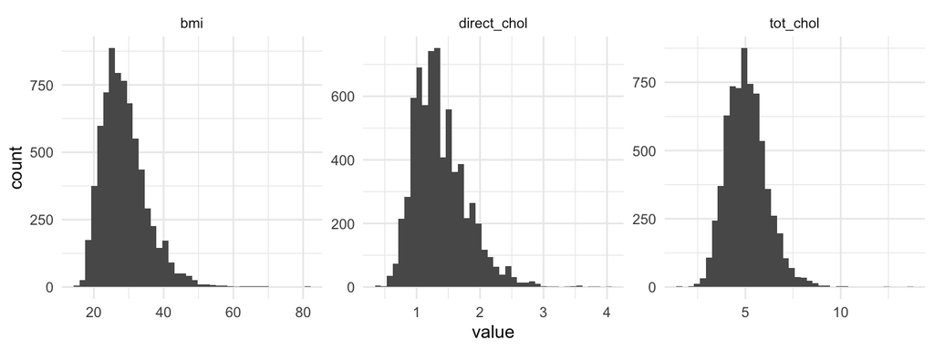

```r
adults |>
  select(bmi, tot_chol, direct_chol) |>
  pivot_longer(everything()) |>
  ggplot(aes(value)) + geom_histogram(bins = 40) +
  facet_wrap(~ name, scales = "free") + theme_minimal()
```

The cholesterol variables (especially HDL, `direct_chol`) are right skewed. We will log them so a few very large values don’t dominate the distances.

**What we learned from looking:**

- Remove duplicate people.
- Use one body-size measure (BMI) and one SBP and one DBP measure (the averages).
- Diabetes is what we want to *report by cluster*, so it should not be used to *make* the clusters.
- We have a mix of numeric and categorical variables. Keep this in mind.

```r
nh <- adults |>
  distinct(id, .keep_all = TRUE) |>
  select(id, age, gender, bmi, weight, height, bp_sys_ave, bp_dia_ave,
         pulse, tot_chol, direct_chol, smoke100, phys_active, diabetes) |>
  drop_na()

glimpse(nh)
```

```
Rows: 4,188
Columns: 14
$ id          <int> 51624, 51630, 51647, 51654, 51656, 51657, 51666, 51667, 51…
$ age         <int> 34, 49, 45, 66, 58, 54, 58, 50, 33, 60, 56, 57, 54, 38, 36…
$ gender      <fct> male, female, female, male, male, male, female, male, male…
$ bmi         <dbl> 32.22, 30.57, 27.24, 23.67, 23.69, 26.03, 26.22, 26.60, 28…
$ weight      <dbl> 87.4, 86.7, 75.7, 68.0, 78.4, 74.7, 57.5, 84.1, 93.8, 74.6…
$ height      <dbl> 164.7, 168.4, 166.7, 169.5, 181.9, 169.4, 148.1, 177.8, 18…
$ bp_sys_ave  <int> 113, 112, 118, 111, 104, 134, 127, 142, 128, 152, 95, 122,…
$ bp_dia_ave  <int> 85, 75, 64, 63, 74, 85, 83, 68, 74, 100, 69, 89, 41, 81, 8…
$ pulse       <int> 70, 86, 62, 60, 62, 76, 94, 74, 96, 84, 64, 70, 64, 60, 68…
$ tot_chol    <dbl> 3.49, 6.70, 5.82, 4.99, 4.24, 6.41, 4.78, 5.22, 5.59, 6.39…
$ direct_chol <dbl> 1.29, 1.16, 2.12, 0.67, 0.96, 1.16, 1.14, 1.06, 0.91, 1.34…
$ smoke100    <fct> Yes, Yes, No, Yes, No, No, Yes, No, Yes, Yes, No, Yes, No,…
$ phys_active <fct> No, No, Yes, Yes, Yes, Yes, Yes, Yes, No, No, Yes, Yes, Ye…
$ diabetes    <fct> No, No, No, No, No, No, No, No, No, No, No, No, No, No, No…
```

## 1.2 Step 2: The “Obvious” Analysis (and What Goes Wrong)

Suppose we turn every variable into a number (categories become 0/1), standardize, and run K-means with $K = 3$, the way we did in the clustering notes.

```r
# Turning factors into numeric variables
X_wrong <- nh |>
  mutate(across(c(gender, smoke100, phys_active, diabetes), \(x) as.numeric(x) - 1)) |>
  select(-id) |>
  scale()

set.seed(1)
km_wrong <- kmeans(X_wrong, centers = 3, nstart = 25)

nh |>
  mutate(cluster = km_wrong$cluster) |>
  group_by(cluster) |>
  summarize(n = n(), pct_diabetes = mean(diabetes == "Yes") * 100,
            pct_male = mean(gender == "male") * 100,
            mean_bmi = mean(bmi), .groups = "drop") |>
  kbl2(digits = 1, caption = "K-means on everything, including diabetes")
```

K-means on everything, including diabetes

| cluster | n | pct_diabetes | pct_male | mean_bmi |
| --- | --- | --- | --- | --- |
| 1 | 479 | 99.6 | 52.2 | 32.7 |
| 2 | 1874 | 0.0 | 91.7 | 29.6 |
| 3 | 1835 | 0.1 | 4.6 | 27.2 |

The three clusters are basically “people with diabetes”, “men without diabetes” and “women without diabetes”. Two problems:

1. **Diabetes was an input**, so of course one cluster is ~100% diabetic. If we then report “diabetes prevalence differs a lot across clusters,” we are reporting something we built in.
2. **0/1 variables dominate.** A 0/1 variable only takes two values, so after standardizing, everyone is either at one end or the other. That makes a big gap, and K-means likes to cut along big gaps. Numeric variables, by contrast, spread people out smoothly.

## 1.3 Step 3: A New Idea, Gower Distance

K-means and PAM, as we used them in the notes, measure similarity with **Euclidean distance** on numbers. That doesn’t make much sense for a category like gender. A common fix for mixed data is **Gower distance**.

For two people $i$ and $j$, Gower distance takes the average over the variables of a per-variable distance between 0 and 1:

- **Numeric variable:** $|x_i - x_j| \,/\, \text{range}(x)$, the difference as a fraction of the variable’s range.
- **Categorical variable:** 0 if the two people are in the same category, 1 if they are different.

Here is a small example with three people and three variables:

```r
toy <- tibble(
  person = c("A", "B", "C"),
  age    = c(30, 40, 70),          # range = 70 - 30 = 40
  bmi    = c(25, 26, 35),          # range = 35 - 25 = 10
  gender = factor(c("female", "male", "female"))
)
toy
```

```
# A tibble: 3 × 4
  person   age   bmi gender
  <chr>  <dbl> <dbl> <fct>
1 A         30    25 female
2 B         40    26 male
3 C         70    35 female
```

By hand, for A vs. B: age $= |30-40|/40 = 0.25$, BMI $= |25-26|/10 = 0.1$, gender $= 1$ (different). Gower $= (0.25 + 0.1 + 1)/3 = 0.45$.

For A vs. C: age $= 40/40 = 1$, BMI $= 10/10 = 1$, gender $= 0$. Gower $= (1 + 1 + 0)/3 = 0.67$.

The `daisy()` function in the `cluster` package does this for us:

```r
daisy(toy |> select(-person), metric = "gower")
```

```
Dissimilarities :
          1         2
2 0.4500000
3 0.6666667 0.8833333

Metric :  mixed ;  Types = I, I, N
Number of objects : 3
```

Notice that B differs from A by only 10 years and 1 BMI point, but still gets a distance of 0.45, mostly because of gender. **A categorical variable always contributes a full 0 or 1, while a numeric variable usually contributes a small fraction.** Keep that in mind.

### 1.3.1 Gower + PAM on NHANES

K-means needs the actual data values (to compute means), but PAM only needs the distances between people, so it works with Gower distance. We tell `pam()` that we’re giving it distances with `diss = TRUE`.

Inputs: age, BMI, average SBP and DBP, pulse, log total cholesterol, log HDL, plus gender, smoking and physical activity. Diabetes stays out.

```r
nh_in <- nh |>
  transmute(age, bmi, bp_sys_ave, bp_dia_ave, pulse,
            log_tot_chol = log(tot_chol), log_hdl = log(direct_chol),
            gender, smoke100, phys_active)

d_gower <- daisy(nh_in, metric = "gower")
```

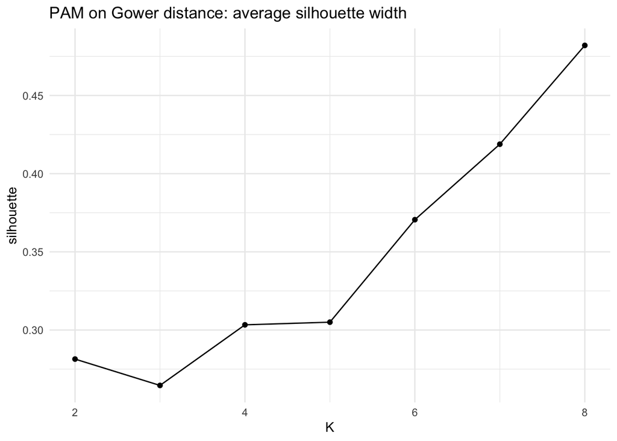

```r
sil_pam <- map_dbl(2:8, function(k) pam(d_gower, k = k, diss = TRUE)$silinfo$avg.width)

tibble(K = 2:8, silhouette = sil_pam) |>
  ggplot(aes(K, silhouette)) + geom_line() + geom_point() +
  labs(title = "PAM on Gower distance: average silhouette width") +
  theme_minimal()
```

```r
pam_g8 <- pam(d_gower, k = 8, diss = TRUE)
nh_in |>
  mutate(cluster = pam_g8$clustering) |>
  count(cluster, gender, smoke100, phys_active) |>
  group_by(cluster) |> slice_max(n, n = 1) |> ungroup() |>
  kbl2(caption = "Most common gender / smoking / activity group in each cluster (K = 8)")
```

Most common gender / smoking / activity group in each cluster (K = 8)

| cluster | gender | smoke100 | phys_active | n |
| --- | --- | --- | --- | --- |
| 1 | male | Yes | No | 543 |
| 2 | female | Yes | No | 443 |
| 3 | female | No | Yes | 686 |
| 4 | male | Yes | Yes | 522 |
| 5 | male | No | Yes | 598 |
| 6 | female | Yes | Yes | 355 |
| 7 | male | No | No | 390 |
| 8 | female | No | No | 651 |

Each cluster is one combination of gender (2) × smoking (2) × activity (2) $= 8$ combinations. The clustering just rebuilt a cross-table of the three categorical variables, which we could have made with `table()`. This is the point from the toy example: in Gower distance, the 0/1 differences of the categorical variables swamp the numeric ones.

**Lesson:** Gower distance is a useful tool for mixed data, but check what the clusters are made of. Here, we want phenotypes based on cardiometabolic *measurements*, so we cluster on the numeric measures and use gender, smoking and activity to *describe* the clusters afterwards.

## 1.4 Step 4: Cluster the Numeric Measures

```r
X_cont <- scale(nh_in |> select(where(is.numeric)))

sil_cont <- map_dbl(2:8, function(k) pam(X_cont, k = k)$silinfo$avg.width)
round(setNames(sil_cont, 2:8), 3)
```

```
    2     3     4     5     6     7     8
0.179 0.141 0.123 0.104 0.103 0.102 0.096
```

The average silhouette widths are all between about 0.10 and 0.18. Recall that values near 1 mean tight, well-separated clusters and values near 0 mean points sit between clusters. No choice of $K$ gives clearly separated groups. We use $K = 3$ (the second largest silhouette, and a small number of groups is easier to describe).

```r
pam_fit <- pam(X_cont, k = 3)

# Medoids are real participants: a "typical person" for each cluster
nh_in[pam_fit$id.med, ] |> kbl2(digits = 2, caption = "PAM medoids (K = 3)")
```

PAM medoids (K = 3)

| age | bmi | bp_sys_ave | bp_dia_ave | pulse | log_tot_chol | log_hdl | gender | smoke100 | phys_active |
| --- | --- | --- | --- | --- | --- | --- | --- | --- | --- |
| 36 | 34.70 | 120 | 76 | 74 | 1.63 | 0.09 | female | Yes | Yes |
| 63 | 27.21 | 139 | 69 | 70 | 1.77 | 0.43 | male | No | Yes |
| 31 | 23.20 | 114 | 67 | 70 | 1.49 | 0.37 | male | Yes | Yes |

## 1.5 Step 5: Are There Clusters at All?

K-means and PAM always return $K$ groups, even if the data are one big cloud. Two checks from the notes:

**A GMM with $G = 1$ allowed.** If BIC picks one component, there’s no evidence of groups.

```r
gmm_fit <- Mclust(X_cont, G = 1:8, verbose = FALSE)
summary(gmm_fit)
```

```
----------------------------------------------------
Gaussian finite mixture model fitted by EM algorithm
----------------------------------------------------

Mclust VVE (ellipsoidal, equal orientation) model with 7 components:

 log-likelihood    n  df       BIC      ICL
      -37914.32 4188 125 -76871.14 -79198.4

Clustering table:
   1    2    3    4    5    6    7
 629  794  811  494 1156   58  246
```

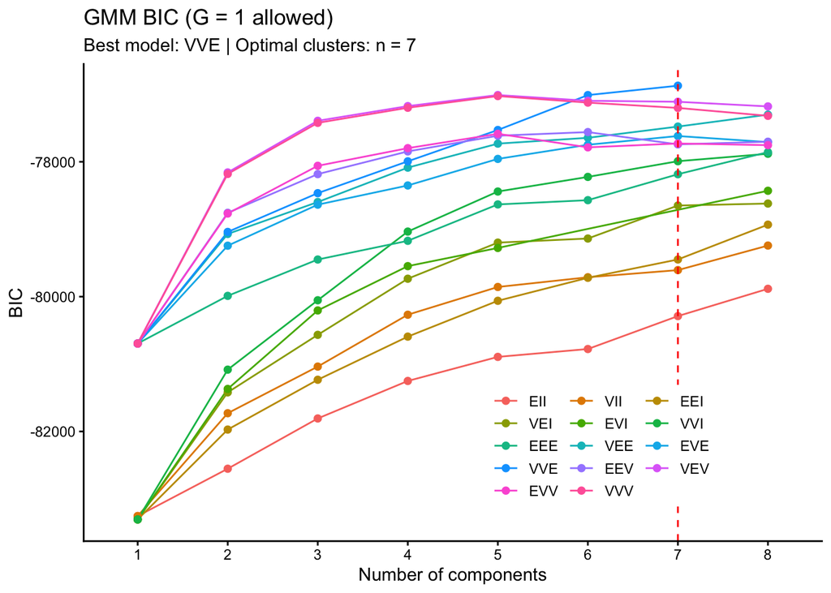

```r
fviz_mclust(gmm_fit, "BIC") + labs(title = "GMM BIC (G = 1 allowed)")
```

BIC picks many components, not one. But a GMM uses components to fit *shape*, too: one skewed cloud can need several normal components to describe it. So this doesn’t prove there are 7 kinds of people.

**A picture.** UMAP of the numeric measures, colored by PAM cluster:

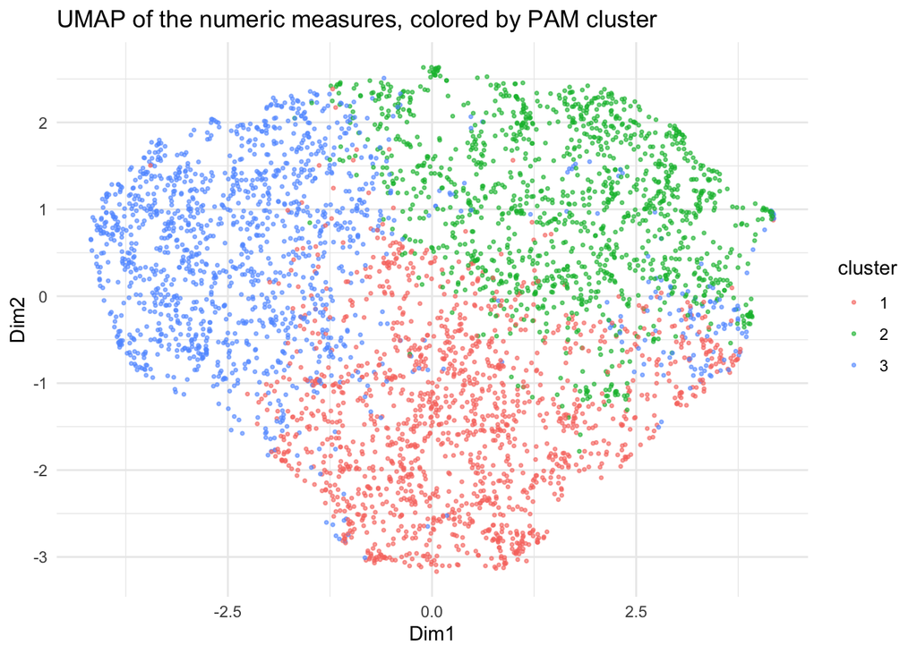

```r
set.seed(1)
umap_nh <- umap(X_cont, n_neighbors = 30)
tibble(Dim1 = umap_nh[, 1], Dim2 = umap_nh[, 2], cluster = factor(pam_fit$clustering)) |>
  ggplot(aes(Dim1, Dim2, color = cluster)) +
  geom_point(size = 0.6, alpha = 0.6) +
  theme_minimal() +
  labs(title = "UMAP of the numeric measures, colored by PAM cluster")
```

One continuous cloud with the clusters as regions of it, not separate islands.

**Do we get the same clusters from different data?** Split the people into two random halves, run PAM on each half separately, and assign *everyone* to the nearest medoid from each half. If the clusters are real, the two halves should give nearly the same assignments (ARI near 1).

```r
nearest_medoid <- function(X, medoids) {
  apply(X, 1, function(x) which.min(colSums((t(medoids) - x)^2)))
}

set.seed(2)
split_ari <- map_dbl(1:10, function(r) {
  half <- sample(nrow(X_cont), nrow(X_cont) / 2)
  fit_a <- pam(X_cont[half, ], k = 3)
  fit_b <- pam(X_cont[-half, ], k = 3)
  adjustedRandIndex(nearest_medoid(X_cont, fit_a$medoids),
                    nearest_medoid(X_cont, fit_b$medoids))
})
round(split_ari, 2)
```

```
 [1] 0.26 0.41 0.25 0.20 0.30 0.27 0.48 0.44 0.23 0.47
```

The average ARI is 0.33. Use this together with the low silhouette and the UMAP picture to judge how much to trust the clusters: these data look like a **continuum**, and the clusters are a convenient way to divide it, not distinct types of people. That’s a perfectly good answer if we report it honestly.

## 1.6 Step 6: Describe the Clusters

Now we bring back the variables we kept out, including diabetes.

```r
nh |>
  mutate(cluster = pam_fit$clustering) |>
  group_by(cluster) |>
  summarize(n = n(),
            age = mean(age), bmi = mean(bmi), sbp = mean(bp_sys_ave),
            hdl = mean(direct_chol), pct_male = mean(gender == "male") * 100,
            pct_smoked = mean(smoke100 == "Yes") * 100,
            pct_diabetes = mean(diabetes == "Yes") * 100, .groups = "drop") |>
  kbl2(digits = 1, caption = "Cluster profiles and diabetes prevalence")
```

Cluster profiles and diabetes prevalence

| cluster | n | age | bmi | sbp | hdl | pct_male | pct_smoked | pct_diabetes |
| --- | --- | --- | --- | --- | --- | --- | --- | --- |
| 1 | 1449 | 42.4 | 34.5 | 120.1 | 1.1 | 58.8 | 44.3 | 13.9 |
| 2 | 1311 | 64.7 | 27.6 | 134.3 | 1.5 | 44.2 | 48.3 | 16.7 |
| 3 | 1428 | 36.5 | 24.5 | 110.0 | 1.5 | 43.6 | 41.2 | 4.1 |

The three clusters: a younger, high-BMI / low-HDL group; an older, high-blood-pressure group; and a young, lean, low-BP group. Diabetes prevalence differs across them, and this time that is a real finding, because diabetes was not used to form the clusters. Gender and smoking are now spread across all three clusters instead of defining them.

**Important**

**Don’t test the variables you clustered on.** It’s fine to compare diabetes across clusters. It is *not* meaningful to run an ANOVA showing that BMI “differs significantly” across clusters: PAM chose the clusters to make BMI (and the other inputs) differ. You’d get tiny p-values even from random noise.

# 2 Scenario 2: Building Scales from a Personality Survey

**Goal:** Turn 25 survey items into a few scores to use as covariates in a study of health behaviors, and compute the same scores for a new group of people next year.

## 2.1 Step 1: Look at the Data

```r
data(bfi)
dim(bfi)
```

```
[1] 2800   28
```

```r
head(bfi)
```

```
      A1 A2 A3 A4 A5 C1 C2 C3 C4 C5 E1 E2 E3 E4 E5 N1 N2 N3 N4 N5 O1 O2 O3 O4
61617  2  4  3  4  4  2  3  3  4  4  3  3  3  4  4  3  4  2  2  3  3  6  3  4
61618  2  4  5  2  5  5  4  4  3  4  1  1  6  4  3  3  3  3  5  5  4  2  4  3
61620  5  4  5  4  4  4  5  4  2  5  2  4  4  4  5  4  5  4  2  3  4  2  5  5
61621  4  4  6  5  5  4  4  3  5  5  5  3  4  4  4  2  5  2  4  1  3  3  4  3
61622  2  3  3  4  5  4  4  5  3  2  2  2  5  4  5  2  3  4  4  3  3  3  4  3
61623  6  6  5  6  5  6  6  6  1  3  2  1  6  5  6  3  5  2  2  3  4  3  5  6
      O5 gender education age
61617  3      1        NA  16
61618  3      2        NA  18
61620  2      2        NA  17
61621  5      2        NA  17
61622  3      1        NA  17
61623  1      2         3  21
```

The first 25 columns are survey items; the last three (`gender`, `education`, `age`) are **not**. They describe the person, and they will probably be separate covariates in the health-behavior regression, so they shouldn’t be mixed into a personality score.

```r
table(bfi$A1, useNA = "ifany")
```

```
   1    2    3    4    5    6 <NA>
 922  818  402  337  223   82   16
```

Each item is an answer from 1 (very inaccurate) to 6 (very accurate), and some people skipped items.

```r
round(cor(bfi[, c("A1", "A2", "A3", "A4", "A5")], use = "pairwise.complete.obs"), 2)
```

```
      A1    A2    A3    A4    A5
A1  1.00 -0.34 -0.27 -0.15 -0.18
A2 -0.34  1.00  0.49  0.34  0.39
A3 -0.27  0.49  1.00  0.36  0.50
A4 -0.15  0.34  0.36  1.00  0.31
A5 -0.18  0.39  0.50  0.31  1.00
```

`A2`–`A5` are positively correlated, but `A1` is *negatively* correlated with all of them. Check the wording (`?bfi`): A1 is “Am indifferent to the feelings of others.” It’s worded in the opposite direction (**reverse keyed**). `bfi.keys` lists which items are reversed (the “-” sign):

```r
bfi.keys
```

```
$agree
[1] "-A1" "A2"  "A3"  "A4"  "A5"

$conscientious
[1] "C1"  "C2"  "C3"  "-C4" "-C5"

$extraversion
[1] "-E1" "-E2" "E3"  "E4"  "E5"

$neuroticism
[1] "N1" "N2" "N3" "N4" "N5"

$openness
[1] "O1"  "-O2" "O3"  "O4"  "-O5"
```

```r
mean(!complete.cases(bfi[, 1:25]))   # share of people who skipped at least one item
```

```
[1] 0.13
```

**What we learned from looking:** use the 25 items only; some items are reversed; about 13% of people skipped at least one item; and the survey was *designed* to measure five traits.

## 2.2 Step 2: Set Aside “Next Year’s” People

We want a scoring rule we can apply to new people. To mimic that, we set aside 800 people as “next year’s cohort” and build the scores using only the other 2,000.

```r
set.seed(3)
idx_new    <- sample(nrow(bfi), 800)
bfi_now    <- bfi[-idx_new, ]
bfi_next   <- bfi[idx_new, ]
items      <- bfi_now |> select(A1:O5)
next_items <- bfi_next |> select(A1:O5)
```

## 2.3 Step 3: The “Obvious” Analysis (and What Goes Wrong)

PCA on the whole data frame:

```r
pca_wrong <- prcomp(drop_na(bfi_now), scale. = TRUE)
round(pca_wrong$rotation[c("gender", "education", "age"), 1:5], 2)
```

```
           PC1   PC2   PC3   PC4  PC5
gender    0.07 -0.16  0.13  0.19 0.15
education 0.02  0.01 -0.09 -0.11 0.33
age       0.08  0.04 -0.03  0.00 0.36
```

Two problems. `drop_na()` quietly threw away everyone who skipped any item (about 13%), and age and education load on PC5 along with the items. A “personality” score that partly measures age is a problem when age is also a covariate in the regression.

A second, subtler issue: PCA summarizes *all* the variance in the items. Our goal is different. We think there are a few underlying traits that cause people to answer the items the way they do, which is exactly what **factor analysis** is built for (see the Dimension Reduction notes).

## 2.4 Step 4: Factor Analysis

Same steps as the notes: check suitability, choose the number of factors, fit.

```r
KMO(items)$MSA   # > 0.6 is acceptable
```

```
[1] 0.8425475
```

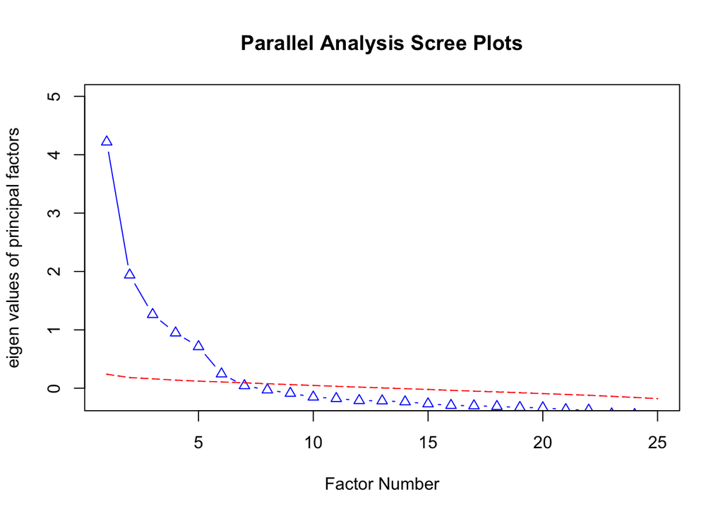

```
Parallel analysis suggests that the number of factors =  6  and the number of components =  NA
```

```r
fa.parallel(items, fa = "fa", n.iter = 20, show.legend = FALSE)
```

Parallel analysis suggests about 6 factors. The survey was designed for 5, so we fit 5 and check that they match the 5 traits. (A 6th factor is often a small one picking up a couple of items with similar wording.)

In the notes we used `rotate = "varimax"`, which forces the factors to be **uncorrelated**. But personality traits can be correlated (people who are more extraverted also tend to be more agreeable). `rotate = "oblimin"` allows the factors to be correlated, and we can look at how correlated they turn out to be.

```r
fa_fit <- fa(items, nfactors = 5, rotate = "oblimin", fm = "ml")
print(fa_fit$loadings, cutoff = 0.3, sort = TRUE)
```

```
Loadings:
   ML4    ML5    ML3    ML1    ML2
N1  0.860
N2  0.818
N3  0.658
E1         0.569
E2         0.696
E4        -0.563  0.317
A2                0.624
A3                0.677
A5                0.544
C1                       0.523
C2                       0.608
C3                       0.554
C4                      -0.660
C5                      -0.573
O1                              0.549
O3                              0.644
O5                             -0.506
A1               -0.387
A4                0.454
E3        -0.342                0.330
E5        -0.370
N4  0.400  0.412
N5  0.432
O2                             -0.446
O4         0.345                0.354

                 ML4   ML5   ML3   ML1   ML2
SS loadings    2.400 1.904 1.898 1.907 1.579
Proportion Var 0.096 0.076 0.076 0.076 0.063
Cumulative Var 0.096 0.172 0.248 0.324 0.388
```

Read down each column: each factor picks up mostly the five items of one trait (in this run ML4 = neuroticism, ML5 = extraversion, ML3 = agreeableness, ML1 = conscientiousness, ML2 = openness). Within a factor, the reversed items have the **opposite sign** from the other items (e.g., A1 is negative while A2–A5 are positive). The overall sign of a factor is arbitrary: ML5 came out “backwards” (E1 and E2 are positive, E3–E5 negative), so ML5 is really *introversion*. Flipping all its signs gives the same model. A few items load on two factors (look for items with two numbers in their row, like N4 and O4); those items don’t cleanly measure just one trait.

```r
round(fa_fit$Phi, 2)   # correlations between the factors
```

```
      ML4   ML5   ML3   ML1   ML2
ML4  1.00  0.23 -0.02 -0.22  0.00
ML5  0.23  1.00 -0.33 -0.22 -0.18
ML3 -0.02 -0.33  1.00  0.18  0.24
ML1 -0.22 -0.22  0.18  1.00  0.18
ML2  0.00 -0.18  0.24  0.18  1.00
```

Several factors are correlated at about 0.2–0.3 (in absolute value), so letting them be correlated (oblimin) was reasonable. With varimax, these would have been forced to 0.

## 2.5 Step 5: Scoring Next Year’s People

The key idea: **build the scoring rule from this year’s data, then apply the same rule to next year’s people.** Don’t redo the factor analysis on next year’s data: you’d get slightly different factors, and the scores wouldn’t be comparable across years.

**Option 1, factor scores.** `predict()` uses the weights from this year’s fit:

```r
fs_next <- predict(fa_fit, data = next_items, old.data = items)
head(round(fs_next, 2))
```

```
        ML4   ML5   ML3   ML1   ML2
62965  1.04  1.80 -1.00 -0.62  1.13
63745  0.68  0.22  0.33 -0.42  0.14
67152 -1.11 -0.39  0.41  1.23  0.65
67454 -1.36  0.64  0.88 -0.16  1.25
63732 -0.72  0.73 -0.47 -0.51 -0.56
62447  1.05 -0.45  1.06  0.59  1.32
```

```r
sum(!complete.cases(fs_next))   # people with no factor scores
```

```
[1] 93
```

Anyone who skipped even one item gets `NA` for all factor scores.

**Option 2, simple scale scores.** For each trait, flip the reversed items (on a 1–6 scale, a reversed answer $x$ becomes $7 - x$) and average the five items, using whatever items the person answered.

```r
reversed <- c("A1", "C4", "C5", "E1", "E2", "O2", "O5")

scale_scores <- function(dat) {
  dat |>
    mutate(across(all_of(reversed), \(x) 7 - x)) |>
    transmute(
      agree         = rowMeans(across(A1:A5), na.rm = TRUE),
      conscientious = rowMeans(across(C1:C5), na.rm = TRUE),
      extraversion  = rowMeans(across(E1:E5), na.rm = TRUE),
      neuroticism   = rowMeans(across(N1:N5), na.rm = TRUE),
      openness      = rowMeans(across(O1:O5), na.rm = TRUE)
    )
}
ss_next <- scale_scores(next_items)
head(round(ss_next, 2))
```

```
      agree conscientious extraversion neuroticism openness
62965   4.0           3.6          2.4         4.8      6.0
63745   5.2           3.8          4.0         4.0      4.8
67152   4.6           5.6          5.0         1.8      5.0
67454   5.8           4.2          3.6         1.8      6.0
63732   4.4           3.8          3.2         2.8      4.4
62447   5.8           4.6          4.8         4.2      5.6
```

How similar are the two options?

```r
round(cor(fs_next, ss_next, use = "pairwise.complete.obs"), 2)
```

```
    agree conscientious extraversion neuroticism openness
ML4 -0.24         -0.24        -0.14        0.96    -0.07
ML5 -0.41         -0.27        -0.93        0.43    -0.06
ML3  0.93          0.28         0.57       -0.07     0.15
ML1  0.34          0.98         0.36       -0.34     0.25
ML2  0.23          0.26         0.44       -0.06     0.92
```

Each factor matches one scale score with a correlation of 0.92 to 0.98 (ML5 is negative with extraversion because, as we saw, ML5 is introversion). Since the simple scale scores are nearly the same, easy to explain, and work for people who skipped an item, they’re a good choice for the regression. Factor analysis did its job: it confirmed that the items group into the five intended traits, so averaging within each trait makes sense.

# 3 Scenario 3: Community Types from the Communities and Crime Data

**Goal:** Find a few community “types” to guide where a violence-prevention program sends resources, compare violent crime across the types, and assign communities that join next year to an existing type.

## 3.1 Step 1: Look at the Data

```r
crime <- readRDS("community_crime.RDS")
dim(crime)
```

```
[1] 1993  101
```

```r
names(crime)
```

```
  [1] "population"            "householdsize"         "racepctblack"
  [4] "racePctWhite"          "racePctAsian"          "racePctHisp"
  [7] "agePct12t21"           "agePct12t29"           "agePct16t24"
 [10] "agePct65up"            "numbUrban"             "pctUrban"
 [13] "medIncome"             "pctWWage"              "pctWFarmSelf"
 [16] "pctWInvInc"            "pctWSocSec"            "pctWPubAsst"
 [19] "pctWRetire"            "medFamInc"             "perCapInc"
 [22] "whitePerCap"           "blackPerCap"           "indianPerCap"
 [25] "AsianPerCap"           "OtherPerCap"           "HispPerCap"
 [28] "NumUnderPov"           "PctPopUnderPov"        "PctLess9thGrade"
 [31] "PctNotHSGrad"          "PctBSorMore"           "PctUnemployed"
 [34] "PctEmploy"             "PctEmplManu"           "PctEmplProfServ"
 [37] "PctOccupManu"          "PctOccupMgmtProf"      "MalePctDivorce"
 [40] "MalePctNevMarr"        "FemalePctDiv"          "TotalPctDiv"
 [43] "PersPerFam"            "PctFam2Par"            "PctKids2Par"
```

[output cut: 19 more lines]

`ViolentCrime` is the **outcome**: we want to compare it across types, so it should not be used to make them.

```r
summary(crime[, c("population", "NumUnderPov", "PctPopUnderPov", "medIncome", "ViolentCrime")])
```

```
   population       NumUnderPov      PctPopUnderPov     medIncome
 Min.   :0.00000   Min.   :0.00000   Min.   :0.0000   Min.   :0.0000
 1st Qu.:0.01000   1st Qu.:0.01000   1st Qu.:0.1100   1st Qu.:0.2000
 Median :0.02000   Median :0.02000   Median :0.2500   Median :0.3200
 Mean   :0.05761   Mean   :0.05551   Mean   :0.3027   Mean   :0.3613
 3rd Qu.:0.05000   3rd Qu.:0.05000   3rd Qu.:0.4500   3rd Qu.:0.4900
 Max.   :1.00000   Max.   :1.00000   Max.   :1.0000   Max.   :1.0000
  ViolentCrime
 Min.   :0.000
 1st Qu.:0.070
 Median :0.150
 Mean   :0.238
 3rd Qu.:0.330
 Max.   :1.000
```

Everything is already between 0 and 1 (the data provider rescaled each variable). But notice the difference between `NumUnderPov` (the *number* of people in poverty) and `PctPopUnderPov` (the *percent* in poverty). A big city has a large number of poor people even if its poverty rate is low.

```r
round(cor(crime$population, crime[, c("numbUrban", "NumUnderPov", "NumIlleg",
                                      "NumImmig", "HousVacant")]), 2)
```

```
     numbUrban NumUnderPov NumIlleg NumImmig HousVacant
[1,]      0.99        0.95     0.89     0.74        0.9
```

The count variables are almost copies of `population`: they mostly measure **how big** the community is. We want types based on what a community is like, not its size, so we leave the counts out.

```r
round(cor(crime[, c("medIncome", "medFamInc", "perCapInc", "PctPopUnderPov")]), 2)
```

```
               medIncome medFamInc perCapInc PctPopUnderPov
medIncome           1.00      0.98      0.89          -0.79
medFamInc           0.98      1.00      0.94          -0.76
perCapInc           0.89      0.94      1.00          -0.70
PctPopUnderPov     -0.79     -0.76     -0.70           1.00
```

```r
r <- cor(crime)
sum(abs(r[upper.tri(r)]) > 0.9)   # pairs of variables that are nearly copies of each other
```

```
[1] 49
```

Many variables measure the same idea (income is measured several ways, immigration 8 ways, divorce 4 ways). In a Euclidean distance, an idea that is measured 8 times counts 8 times. This is exactly the situation where **PCA first** helps: PCA combines highly correlated variables into one component.

**What we learned from looking:** leave out `ViolentCrime` and the count variables; expect PCA to absorb the overlapping variables.

```r
count_vars <- c("population", "numbUrban", "NumUnderPov", "NumIlleg", "NumImmig",
                "NumInShelters", "NumStreet", "HousVacant", "LandArea")
```

## 3.2 Step 2: Set Aside “Next Year’s” Communities

```r
set.seed(4)
idx_new   <- sample(nrow(crime), round(0.2 * nrow(crime)))
crime_now <- crime[-idx_new, ]
crime_new <- crime[idx_new, ]
```

## 3.3 Step 3: The “Obvious” Analysis (and What Goes Wrong)

```r
set.seed(1)
km_all <- kmeans(scale(crime_now), centers = 4, nstart = 25)

crime_now |>
  mutate(cluster = km_all$cluster) |>
  group_by(cluster) |>
  summarize(n = n(), population = mean(population),
            violent_crime = mean(ViolentCrime), .groups = "drop") |>
  kbl2(digits = 3, caption = "K-means on everything (including counts and the outcome)")
```

K-means on everything (including counts and the outcome)

| cluster | n | population | violent_crime |
| --- | --- | --- | --- |
| 1 | 632 | 0.028 | 0.104 |
| 2 | 166 | 0.076 | 0.424 |
| 3 | 742 | 0.039 | 0.285 |
| 4 | 54 | 0.650 | 0.672 |

One small cluster is just the biggest cities (look at its average population), because they are extreme on every count variable at once. And since `ViolentCrime` was an input, the “high crime” cluster is partly high-crime by construction.

## 3.4 Step 4: PCA on the Rate Variables

```r
X_now <- crime_now |> select(-ViolentCrime, -all_of(count_vars))
ncol(X_now)
```

```
[1] 91
```

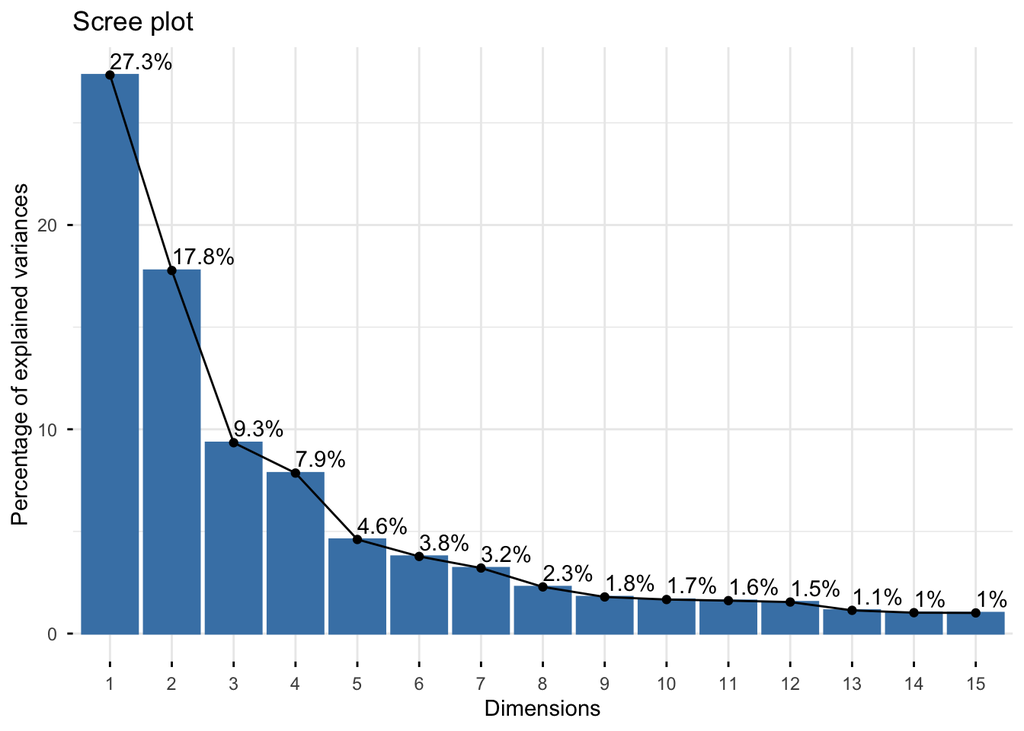

```r
pca_fit <- prcomp(X_now, center = TRUE, scale. = TRUE)
fviz_eig(pca_fit, ncp = 15, addlabels = TRUE) + labs(title = "Scree plot")
```

```r
round(cumsum(pca_fit$sdev^2 / sum(pca_fit$sdev^2))[1:10], 2)
```

```
 [1] 0.27 0.45 0.54 0.62 0.67 0.71 0.74 0.76 0.78 0.80
```

The first 6 components explain about 70% of the variance in 91 variables. After that, each extra component adds only a few percent. We keep 6.

What do the components mean? Look at the variables with the largest loadings:

```r
map_dfr(1:4, function(j) {
  l <- pca_fit$rotation[, j]
  top <- names(sort(abs(l), decreasing = TRUE))[1:6]
  tibble(PC = paste0("PC", j), variable = top, loading = round(l[top], 2))
}) |>
  kbl2(caption = "Largest loadings on PCs 1–4")
```

Largest loadings on PCs 1–4

| PC | variable | loading |
| --- | --- | --- |
| PC1 | medFamInc | 0.19 |
| PC1 | medIncome | 0.19 |
| PC1 | pctWInvInc | 0.18 |
| PC1 | PctPopUnderPov | -0.18 |
| PC1 | PctKids2Par | 0.17 |
| PC1 | perCapInc | 0.17 |
| PC2 | PctRecImmig10 | 0.23 |
| PC2 | PctRecImmig8 | 0.23 |
| PC2 | PctRecImmig5 | 0.22 |
| PC2 | PctRecentImmig | 0.22 |
| PC2 | PctForeignBorn | 0.22 |
| PC2 | PctSpeakEnglOnly | -0.20 |
| PC3 | PersPerOccupHous | 0.27 |
| PC3 | PersPerFam | 0.25 |
| PC3 | PersPerOwnOccHous | 0.24 |
| PC3 | householdsize | 0.22 |
| PC3 | PctLargHouseOccup | 0.20 |
| PC3 | PersPerRentOccHous | 0.20 |
| PC4 | agePct12t21 | 0.25 |
| PC4 | agePct12t29 | 0.24 |
| PC4 | PctSameCity85 | -0.24 |
| PC4 | agePct65up | -0.24 |
| PC4 | PctSameHouse85 | -0.23 |
| PC4 | agePct16t24 | 0.22 |

PC1 is income and poverty (an economic advantage axis), PC2 is immigration and language, PC3 is household size, and PC4 is age of the population and how long people have lived there. The 8 immigration variables now count *once* (in PC2) instead of 8 times.

## 3.5 Step 5: Cluster the PC Scores

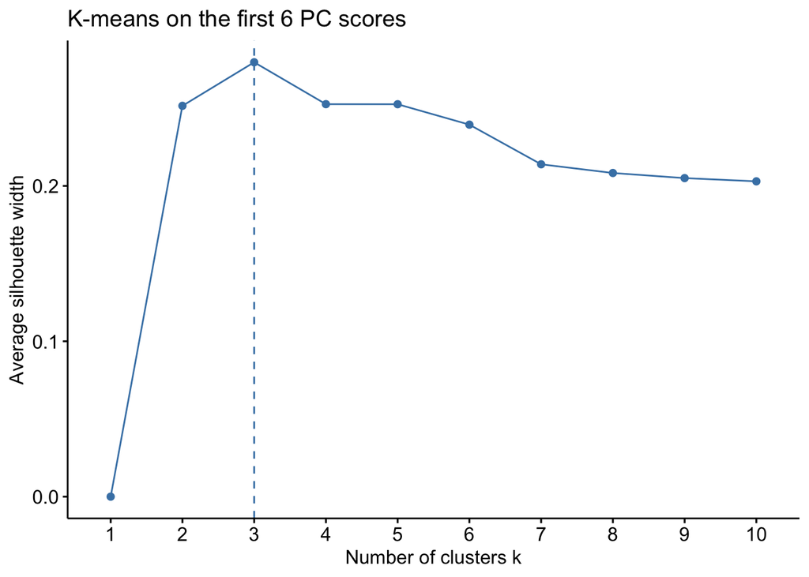

```r
n_pc <- 6
S_now <- pca_fit$x[, 1:n_pc]

fviz_nbclust(S_now, kmeans, method = "silhouette", k.max = 10) +
  labs(title = "K-means on the first 6 PC scores")
```

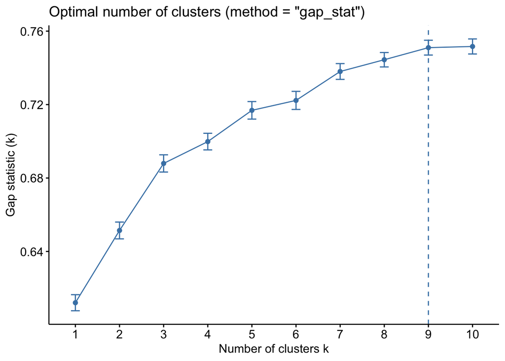

```r
set.seed(5)
gap <- clusGap(S_now, FUN = kmeans, nstart = 25, iter.max = 50, K.max = 10, B = 30)
fviz_gap_stat(gap)
```

The silhouette is highest at $K = 3$, but only about 0.28 (weak structure). The gap statistic keeps increasing all the way to 9, which usually means there are no clearly separated groups. We go with $K = 3$; a program also needs a small number of types to be useful.

```r
set.seed(6)
K <- 3
km_pc <- kmeans(S_now, centers = K, nstart = 50)

crime_now |>
  mutate(type = km_pc$cluster) |>
  group_by(type) |>
  summarize(n = n(),
            medIncome = mean(medIncome), PctPopUnderPov = mean(PctPopUnderPov),
            PctKids2Par = mean(PctKids2Par), PctForeignBorn = mean(PctForeignBorn),
            pctUrban = mean(pctUrban),
            violent_crime = mean(ViolentCrime), .groups = "drop") |>
  kbl2(digits = 2, caption = "Community types (K-means on 6 PCs) and violent crime")
```

Community types (K-means on 6 PCs) and violent crime

| type | n | medIncome | PctPopUnderPov | PctKids2Par | PctForeignBorn | pctUrban | violent_crime |
| --- | --- | --- | --- | --- | --- | --- | --- |
| 1 | 180 | 0.31 | 0.46 | 0.49 | 0.69 | 0.83 | 0.44 |
| 2 | 640 | 0.56 | 0.10 | 0.80 | 0.22 | 0.85 | 0.10 |
| 3 | 774 | 0.21 | 0.43 | 0.50 | 0.11 | 0.54 | 0.31 |

The three types: (1) a small group of urban communities with many immigrants, (2) higher-income communities with many two-parent families, and (3) a larger group of lower-income, less urban communities. Average violent crime is highest in type 1 and lowest in type 2.

Comparing crime across types is fair now, because `ViolentCrime` wasn’t used to make them. It is still a description, though: it doesn’t show that these community characteristics *cause* crime.

## 3.6 Step 6: A Picture with UMAP

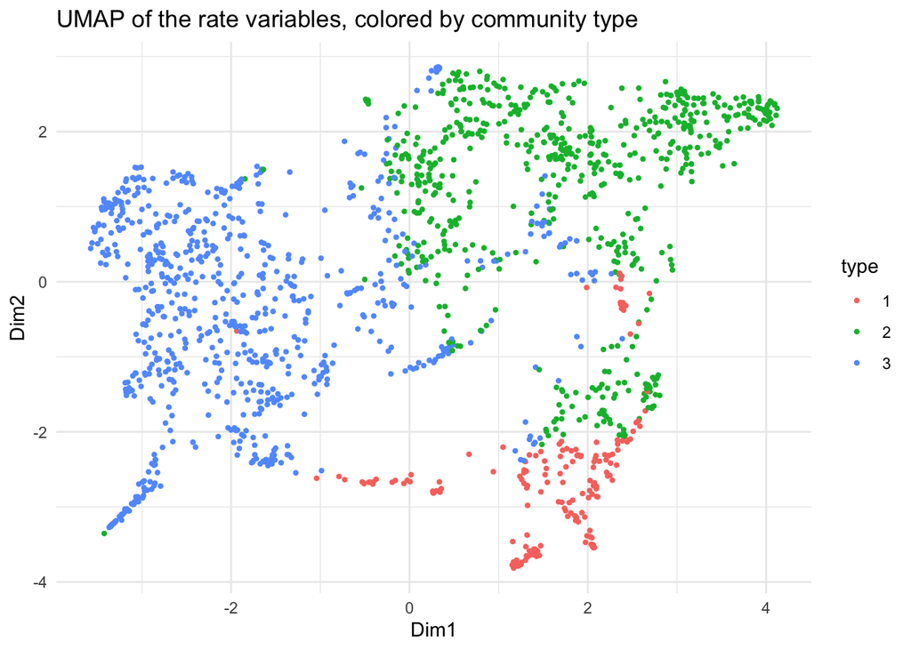

```r
set.seed(7)
umap_fit <- umap(scale(X_now), n_neighbors = 30)
tibble(Dim1 = umap_fit[, 1], Dim2 = umap_fit[, 2], type = factor(km_pc$cluster)) |>
  ggplot(aes(Dim1, Dim2, color = type)) +
  geom_point(size = 0.8) + theme_minimal() +
  labs(title = "UMAP of the rate variables, colored by community type")
```

We found the types with PCA + K-means and only use UMAP to *look*. The types are regions of one cloud rather than separate islands, which matches the low silhouette.

## 3.7 Step 7: Assigning Next Year’s Communities

To assign a new community, we apply this year’s steps without refitting anything:

1. Use this year’s PCA (same centering, scaling and loadings) to compute the new community’s 6 PC scores. `predict()` does this for `prcomp` objects.
2. Put the community in the type whose K-means center is closest.

```r
X_new <- crime_new |> select(-ViolentCrime, -all_of(count_vars))
S_new <- predict(pca_fit, newdata = X_new)[, 1:n_pc]

nearest_center <- function(S, centers) {
  apply(S, 1, function(s) which.min(colSums((t(centers) - s)^2)))
}
type_new <- nearest_center(S_new, km_pc$centers)
table(type_new)
```

```
type_new
  1   2   3
 35 158 206
```

Would we get the same types if we had refit everything with the new communities included?

```r
X_all   <- bind_rows(X_now, X_new)
pca_all <- prcomp(X_all, center = TRUE, scale. = TRUE)
set.seed(6)
km_all2 <- kmeans(pca_all$x[, 1:n_pc], centers = K, nstart = 50)

adjustedRandIndex(type_new, km_all2$cluster[(nrow(X_now) + 1):nrow(X_all)])
```

```
[1] 0.9401175
```

An ARI near 1 means the fixed rule and a full refit agree, so the types don’t depend much on which communities happened to be in this year’s data.

**Important**

**Why not t-SNE or MDS?** Neither one has a way to place a new community into an existing picture. Adding communities means rerunning the whole embedding, which moves *everyone* and can change the types. PCA (plus K-means centers) gives a fixed rule we can reuse.

# 4 Summary of the Debrief

|  | Group 1 (NHANES) | Group 2 (bfi) | Group 3 (Communities) |
| --- | --- | --- | --- |
| What we found by looking | duplicate people, overlapping variables, mixed types, outcome in the data | demographic columns, reversed items, skipped items | outcome in the data, count variables, many overlapping variables |
| What we left out | duplicates, `diabetes`, extra body-size and BP measures | `gender`, `education`, `age` | `ViolentCrime`, count variables |
| Method | PAM on the numeric measures (Gower was tried and explained) | Factor analysis (oblimin), then simple scale scores | PCA, then K-means on 6 PC scores |
| How many? | silhouette | parallel analysis + the survey design | scree plot; silhouette and gap |
| Is it real? | low silhouette, GMM, UMAP, split-half ARI: a continuum | loadings match the 5 designed traits | low silhouette, UMAP: a continuum, but a stable one |
| New data | not needed | same scoring rule applied to next year | `predict()` PCA, nearest center |